# Study 3 Analysis

Liam A. Doyle

2024-05-03

## Demographics of Sample

To get a basic picture of the sample being used for analysis, descriptives were run for common demographic variables (e.g., age, gender).

```
##    vars   n  mean   sd median trimmed  mad min max range skew kurtosis  se
## X1    1 363 20.18 3.82     19   19.35 1.48   1  42    41 2.27      9.8 0.2
```

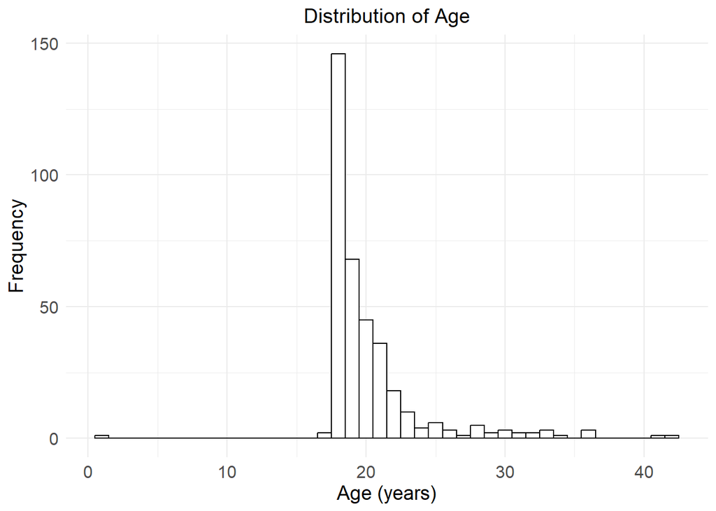

```
## # A tibble: 7 × 3
##   Race           Frequency Percentage
##   <chr>              <int>      <dbl>
## 1 White                259      71.2
## 2 Asian                 40      11.0
## 3 Black                 29       7.97
## 4 Multiracial           16       4.40
## 5 Arabic                10       2.75
## 6 Latin American         5       1.37
## 7 <NA>                   5       1.37
```

```
## # A tibble: 3 × 3
##   Gender     Frequency Percentage
##   <chr>          <int>      <dbl>
## 1 Man               64      17.6
## 2 Non-Binary        11       3.02
## 3 Woman            289      79.4
```

```
## # A tibble: 2 × 3
##   Sex    Frequency Percentage
##   <chr>      <int>      <dbl>
## 1 Female       302       83.0
## 2 Male          62       17.0
```

## Creating a Table with Descriptive Statistics for Important Variables in the Study

An APA 7 style table was created with the descriptive statistics for important variables in the study (e.g., OS_Avg).

```
##             vars   n  mean   sd median trimmed  mad    min   max range  skew
## OS_Avg         1 364  0.53 0.24   0.50    0.52 0.15   0.00  1.00  1.00  0.02
## OSF_Avg        2 364 10.09 2.76  10.00   10.12 2.97   1.50 18.00 16.50 -0.07
## Diff_OS_Avg    3 364  0.46 5.85   0.00    0.46 5.93 -18.00 16.00 34.00  0.00
## IT_Avg         4 364  0.52 0.34   0.60    0.53 0.44   0.00  1.00  1.00 -0.33
## ITF_Avg        5 364 10.61 2.90  10.00   10.56 2.97   6.50 15.50  9.00  0.33
## Diff_IT_Avg    6 364  1.14 0.99   2.00    1.18 0.00   0.00  2.50  2.50 -0.29
## SRP_Total      7 364  2.18 0.47   2.14    2.15 0.46   1.22  4.25  3.03  0.70
## IES_Avg        8 364  2.11 1.18   1.83    1.93 1.23   1.00  7.00  6.00  1.16
## BZSG_Avg       9 364  3.43 1.02   3.50    3.44 0.92   1.00  6.00  5.00 -0.15
##             kurtosis   se
## OS_Avg         -0.18 0.01
## OSF_Avg        -0.07 0.14
## Diff_OS_Avg    -0.16 0.31
## IT_Avg         -1.24 0.02
## ITF_Avg        -1.21 0.15
## Diff_IT_Avg    -1.92 0.05
## SRP_Total       0.77 0.02
## IES_Avg         0.94 0.06
## BZSG_Avg       -0.20 0.05
```

## Correlation Matrix Between Major Variables

Self-explanatory. Correlations between important variables in the study (i.e., variables relevant to hypothesis testing).

```
##                 OS_Avg     OSF_Avg Diff_OS_Avg      IT_Avg    ITF_Avg
## OS_Avg       1.0000000  0.43495046   0.8244163  0.57479694 -0.5689408
## OSF_Avg      0.4349505  1.00000000   0.8682229  0.30610610 -0.3073510
## Diff_OS_Avg  0.8244163  0.86822289   1.0000000  0.50913253 -0.5066881
## IT_Avg       0.5747969  0.30610610   0.5091325  1.00000000 -0.9858474
## ITF_Avg     -0.5689408 -0.30735099  -0.5066881 -0.98584737  1.0000000
## Diff_IT_Avg  0.4239281  0.20234704   0.3607816  0.75539188 -0.6351196
## SRP_Total    0.1163632  0.07791014   0.1130899  0.08566663 -0.0895238
## IES_Avg      0.1333215  0.13153599   0.1561411  0.12080249 -0.1280356
##             Diff_IT_Avg   SRP_Total     IES_Avg
## OS_Avg       0.42392809  0.11636324  0.13332154
## OSF_Avg      0.20234704  0.07791014  0.13153599
## Diff_OS_Avg  0.36078164  0.11308995  0.15614115
## IT_Avg       0.75539188  0.08566663  0.12080249
## ITF_Avg     -0.63511963 -0.08952380 -0.12803558
## Diff_IT_Avg  1.00000000  0.04719509  0.05518771
## SRP_Total    0.04719509  1.00000000  0.69313406
## IES_Avg      0.05518771  0.69313406  1.00000000
```

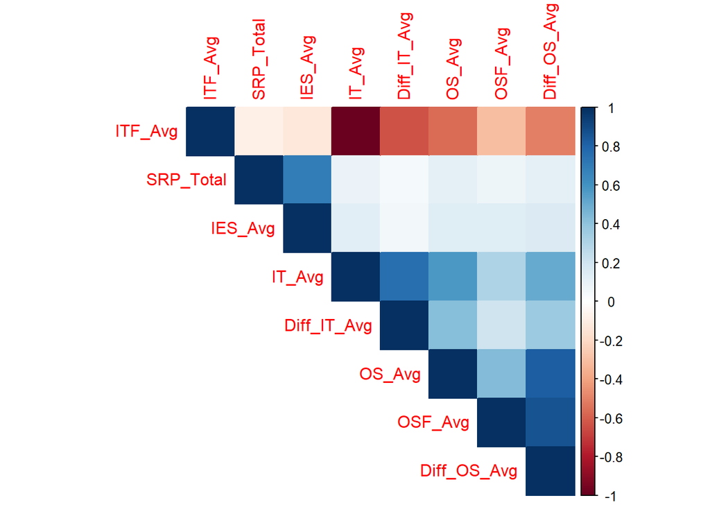

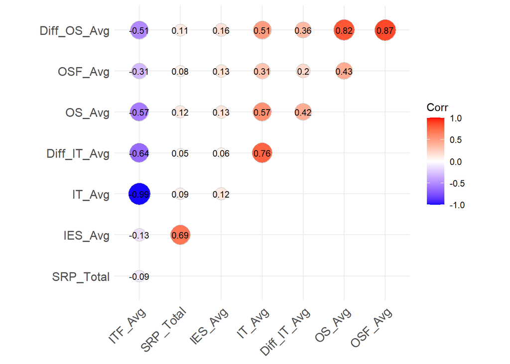

## Hypothesis 1: Psychopathy and Exploitation in the PDG

```
## Call:
## pbcor(x = data$PDG_Avg, y = data$SRP_Total, ci = TRUE, nboot = 1000)
##
## Robust correlation coefficient: 0.1291
## Test statistic: 2.4779
## p-value: 0.01367
##
## Bootstrap CI: [0.0232; 0.2259]
```

## Hypothesis 2: Psychopathy and Success in the PDG (Average Payoff)

```
## Call:
## pbcor(x = data$PDGF_Avg, y = data$SRP_Total, ci = TRUE, nboot = 1000)
##
## Robust correlation coefficient: -0.0076
## Test statistic: -0.1453
## p-value: 0.88455
##
## Bootstrap CI: [-0.1107; 0.0948]
```

## Hypothesis 3: Psychopathy and Success in the PDG

I also wanted to examine the association between psychopathy and success (i.e., payoff) in the PDG using relative payoffs.

```
## Call:
## pbcor(x = data$Diff_Avg, y = data$SRP_Total, ci = TRUE, nboot = 1000)
##
## Robust correlation coefficient: 0.1404
## Test statistic: 2.6977
## p-value: 0.00731
##
## Bootstrap CI: [0.0384; 0.2289]
```

## Hypothesis 4: Examining the Moderating Effect of Game Type on the Psychopathy-Exploitation Relationship

One of the central questions of this study was whether the game type (i.e., one-shot vs. iterated) moderated the association between psychopathy and exploitation. For this (and subsequent) analysis, the dataset was transformed to a long format for moderation analysis. A mixed effects model was used to account for the dependency between data points (i.e., via participants).

|  | Decision |  |  |  |  |  |
| --- | --- | --- | --- | --- | --- | --- |
| Predictors | Estimates | std. Beta | CI | standardized CI | p | std. p |
| (Intercept) | 0.39 | 0.00 | 0.25 – 0.54 | -0.10 – 0.10 | **<0.001** | 0.969 |
| SRP Total | 0.06 | 0.10 | -0.00 – 0.13 | -0.01 – 0.20 | 0.070 | 0.070 |
| Game Type [Iterated] | -0.01 | -0.00 | -0.15 – 0.13 | -0.10 – 0.09 | 0.926 | 0.935 |
| SRP Total × Game Type [Iterated] | 0.00 | 0.00 | -0.06 – 0.07 | -0.09 – 0.10 | 0.938 | 0.938 |
| Random Effects |  |  |  |  |  |  |
| σ<sup>2</sup> | 0.04 |  |  |  |  |  |
| τ<sub>00</sub> <sub>Participant_ID</sub> | 0.05 |  |  |  |  |  |
| ICC | 0.54 |  |  |  |  |  |
| N <sub>Participant_ID</sub> | 364 |  |  |  |  |  |
| Observations | 728 |  |  |  |  |  |
| Marginal R<sup>2</sup> / Conditional R<sup>2</sup> | 0.009 / 0.542 |  |  |  |  |  |

```
## # (Average) Linear trend for SRP_Total
##
## Game_Type | Slope |      95% CI |     p
## ---------------------------------------
## One-shot  |  0.06 |  0.00, 0.13 | 0.070
## Iterated  |  0.06 |  0.00, 0.13 | 0.059
```

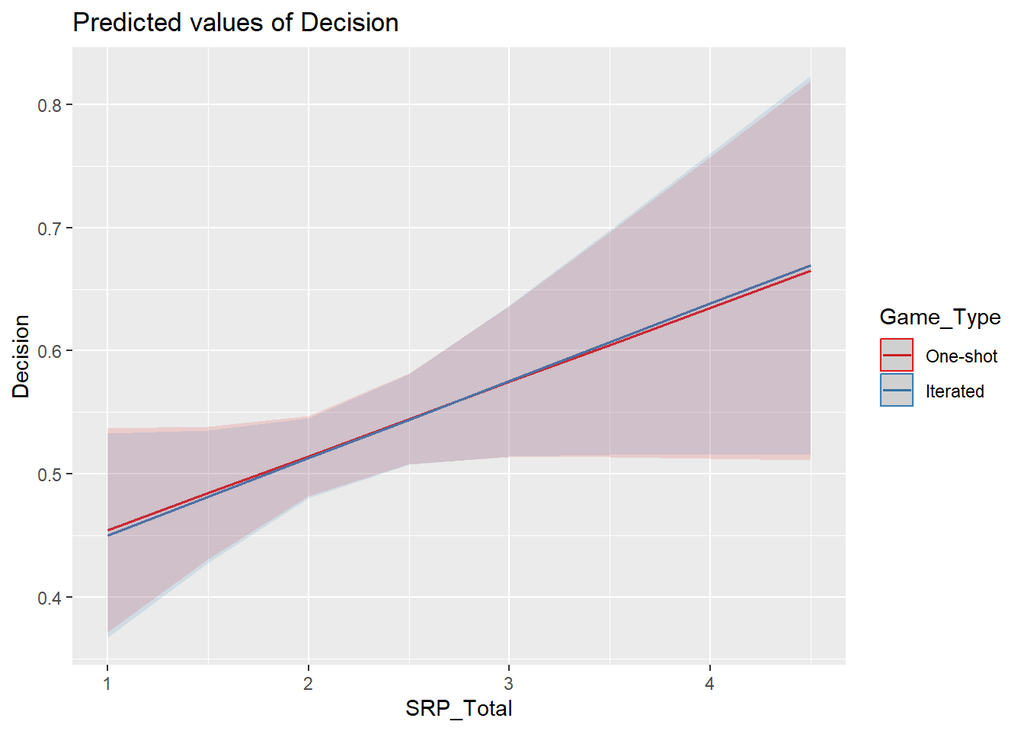

## Hypothesis 5: Examining the Moderating Effect of Game Type on the Psychopathy-Success Relationship (Average Payoff)

Another central question in this study was whether the association between psychopathy and success (as meaured via average payoff) varied as a function of game type (i.e., one-shot vs. iterated) produced significantly different associations between psychopathy and success (as measured via average payoff) Analysis was conducted in the same manner as Hypothesis 4.

|  | Average_Payoff |  |  |  |  |  |
| --- | --- | --- | --- | --- | --- | --- |
| Predictors | Estimates | std. Beta | CI | standardized CI | p | std. p |
| (Intercept) | 9.08 | -0.09 | 7.70 – 10.47 | -0.20 – 0.01 | **<0.001** | 0.075 |
| SRP Total | 0.46 | 0.08 | -0.16 – 1.08 | -0.03 – 0.18 | 0.147 | 0.147 |
| Game Type [Iterated] | 2.74 | 0.19 | 0.78 – 4.70 | 0.04 – 0.33 | **0.006** | **0.012** |
| SRP Total × Game Type [Iterated] | -1.01 | -0.17 | -1.89 – -0.13 | -0.31 – -0.02 | **0.024** | **0.024** |
| Random Effects |  |  |  |  |  |  |
| σ<sup>2</sup> | 7.96 |  |  |  |  |  |
| τ<sub>00</sub> <sub>Participant_ID</sub> | 0.00 |  |  |  |  |  |
| N <sub>Participant_ID</sub> | 364 |  |  |  |  |  |
| Observations | 728 |  |  |  |  |  |
| Marginal R<sup>2</sup> / Conditional R<sup>2</sup> | 0.016 / NA |  |  |  |  |  |

```
## # (Average) Linear trend for SRP_Total
##
## Game_Type | Slope |      95% CI |     p
## ---------------------------------------
## One-shot  |  0.46 | -0.16, 1.08 | 0.147
## Iterated  | -0.56 | -1.18, 0.07 | 0.080
```

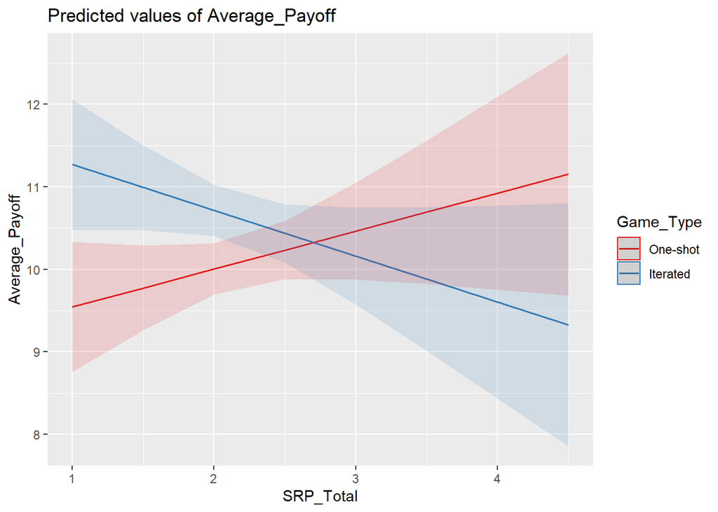

## Hypothesis 6: Examining the Moderating Effect of Game Type on the Psychopathy-Success Relationship (Relative Payoff)

Lastly, the same moderation analysis from Hypothesis 5 was conducted with relative payoff as the outcome measure.

|  | Relative_Payoff |  |  |  |  |  |
| --- | --- | --- | --- | --- | --- | --- |
| Predictors | Estimates | std. Beta | CI | standardized CI | p | std. p |
| (Intercept) | -2.63 | -0.08 | -4.68 – -0.58 | -0.18 – 0.02 | **0.012** | 0.116 |
| SRP Total | 1.42 | 0.16 | 0.50 – 2.34 | 0.05 – 0.26 | **0.003** | **0.003** |
| Game Type [Iterated] | 3.56 | 0.16 | 0.83 – 6.28 | 0.03 – 0.30 | **0.011** | **0.018** |
| SRP Total × Game Type [Iterated] | -1.32 | -0.15 | -2.54 – -0.09 | -0.28 – -0.01 | **0.035** | **0.035** |
| Random Effects |  |  |  |  |  |  |
| σ<sup>2</sup> | 15.34 |  |  |  |  |  |
| τ<sub>00</sub> <sub>Participant_ID</sub> | 2.07 |  |  |  |  |  |
| ICC | 0.12 |  |  |  |  |  |
| N <sub>Participant_ID</sub> | 364 |  |  |  |  |  |
| Observations | 728 |  |  |  |  |  |
| Marginal R<sup>2</sup> / Conditional R<sup>2</sup> | 0.019 / 0.136 |  |  |  |  |  |

```
## # (Average) Linear trend for SRP_Total
##
## Game_Type | Slope |      95% CI |     p
## ---------------------------------------
## One-shot  |  1.42 |  0.50, 2.34 | 0.003
## Iterated  |  0.10 | -0.82, 1.02 | 0.831
```

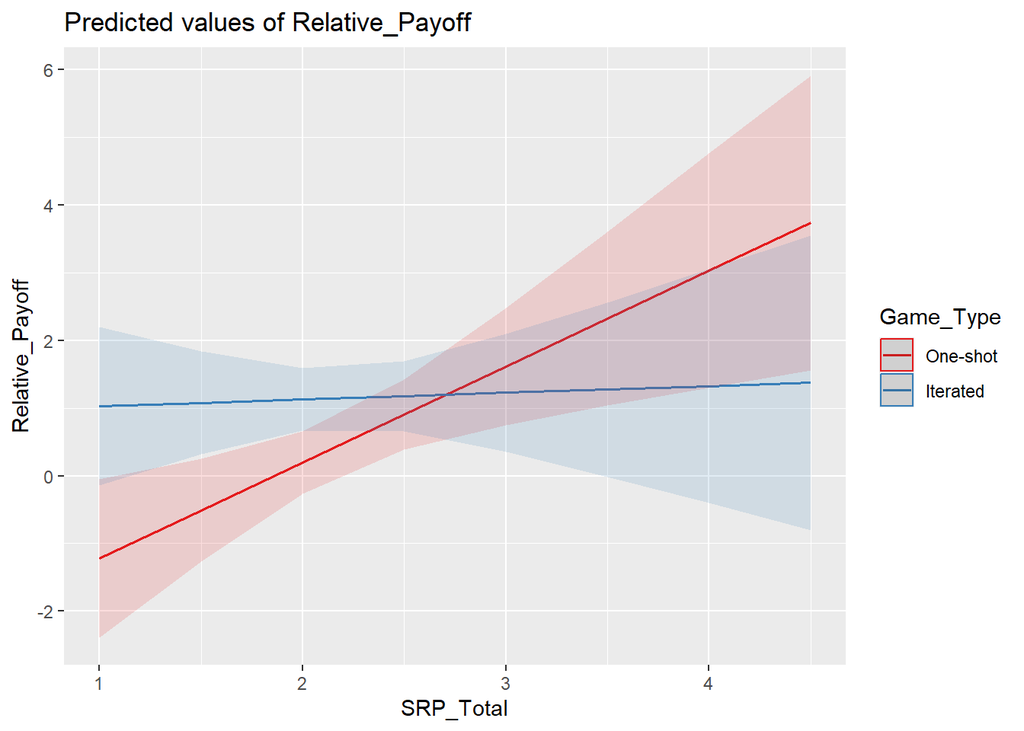